# Week 8 HW - 624

Jeff Shamp

2021-03-25

```r
library(fpp2)
library(httr)
```

# Question HA 8.1

## Question

Figure 8.31 shows the ACFs for 36 random numbers, 360 random numbers and 1,000 random numbers.

## Answer

### Part A

Explain the differences among these figures. Do they all indicate that the data are white noise?

**Ans** : Data in all the 3 figures resemble white noise.The difference between all these figures is the critical values for each dataset, as the dataset is small the critical values are larger and as the dataset increases the critical values are smaller.

### Part B

Why are the critical values at different distances from the mean of zero? Why are the autocorrelations different in each figure when they each refer to white noise?

**Ans** : Critical values are at different distances from the mean of zero, the formula to calculate critical values is
$$\pm 2/\sqrt { N }$$
where N=length of TS. As the length of TS increases or decreases the critical values come closer or move further away from mean of zero.

The autocorrelations are different in each figure because of the different length of each timeseries.

# Question HA 8.2

## Question

A classic example of a non-stationary series is the daily closing IBM stock price series (data set `ibmclose`). Use R to plot the daily closing prices for IBM stock and the ACF and PACF. Explain how each plot shows that the series is non-stationary and should be differenced.

## Answer

First, the autoplot.

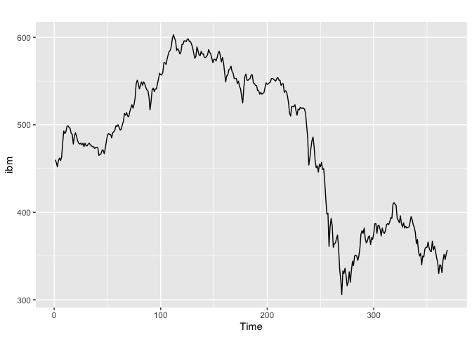

```r
ibm <- ibmclose
autoplot(ibm)
```

The timeseries appears to have some trend component (generally downward, sorry, IBM), which would make the data non-stationary. Taking either the first or second difference should remove this trend and make the data stationary.

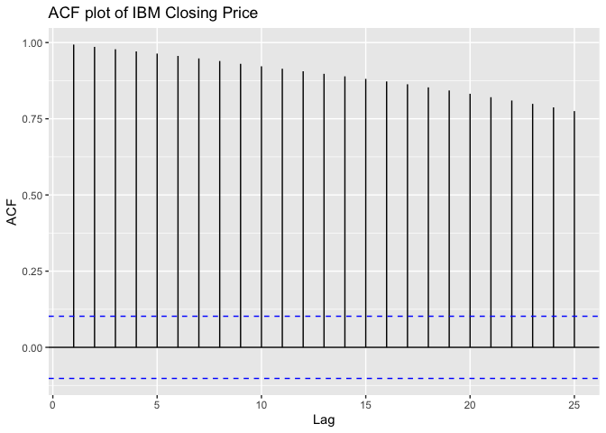

```r
ggAcf(ibm) +
  ggtitle("ACF plot of IBM Closing Price")
```

Here we see an autocorrelation plot that agrees with our initial assumptions; the decreacing values are a clear sign of trend, and every lag has a significant autocorrelation. This data is non-stationary data.

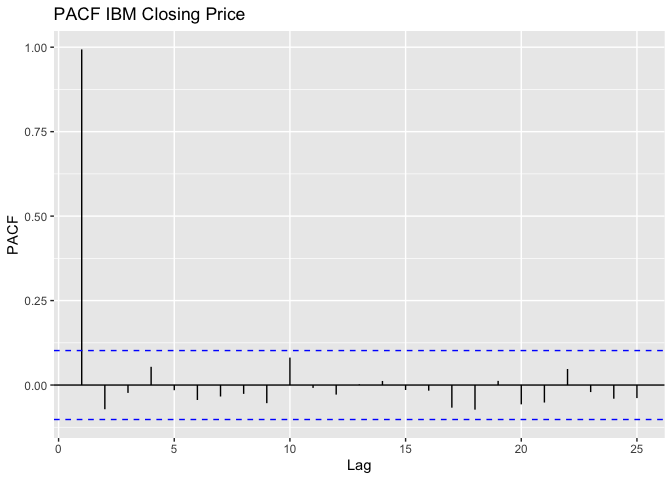

```r
ggPacf(ibm) +
  ggtitle("PACF IBM Closing Price")
```

All of the autocorrelations are explainable by the first lag, the other correlations being significant are a product of this. Basically, for each lag the autocorrelation depends most significantly on the previous value. Again, this correlation indicates non-stationary data which can likely be fixed by a first difference.

# Question HA 8.3

## Question

For the following series, find an appropriate Box-Cox transformation and order differencing in order to obtain stationary data.

1. usnetelec
2. usgdp
3. mcopper
4. enplanements

## Answer

We have done these data set previously for Box-Cox only. For all of these, we will first show the autoplot, then the BC trans, then order differencing. Then we will weigh the merits of using either BC or order differencing for this data is appropriate.

### Part A

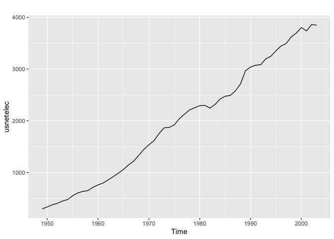

```r
autoplot(usnetelec)
```

Trended data, but no apparent seasonality. A first difference should be adequate.

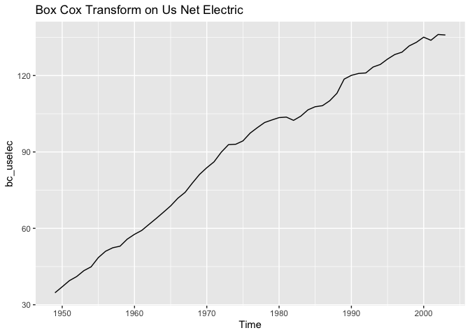

```r
lamb<- BoxCox.lambda(usnetelec)
bc_uselec<- BoxCox(usnetelec, lamb)
autoplot(bc_uselec) + ggtitle("Box Cox Transform on Us Net Electric")
```

This seems like a nice transformation that levels out the scoop in the data from 1960-1970, reduces the scale, and irons out some the variation in 1980-1990.

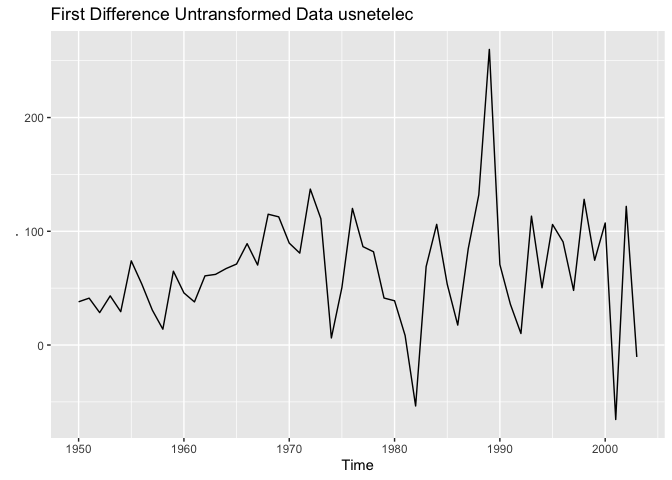

```r
usnetelec %>%
  diff() %>%
  autoplot() + ggtitle("First Difference Untransformed Data usnetelec")
```

One might get upset about a seemingly non-constant variance from 1950-1970, so let’s see if the Box Cox transformation fixes that apparent increase in variation.

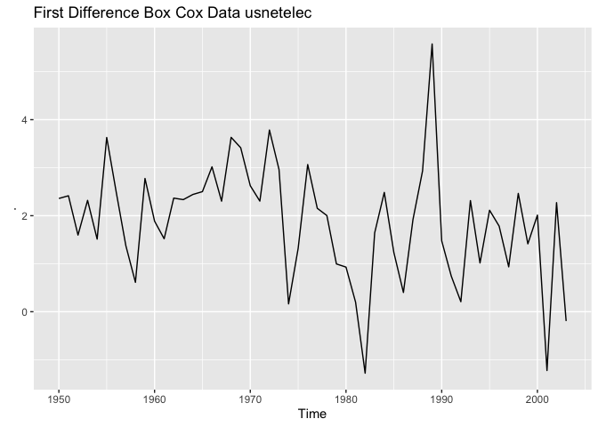

```r
usnetelec %>%
  BoxCox(lambda=lamb) %>%
  diff() %>%
  autoplot() + ggtitle("First Difference Box Cox Data usnetelec")
```

Looks good. Box Cox worked well here with the first difference.

### Part B

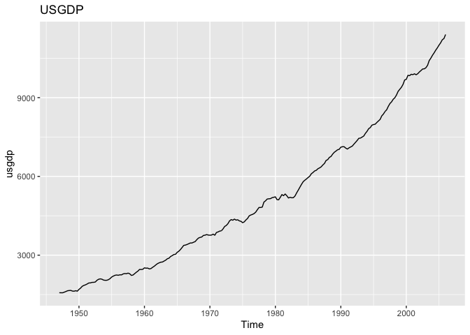

```r
autoplot(usgdp) + ggtitle("USGDP")
```

Again, trended data with no apparent seasonality - tried a seasonality plot and subseries to confirm that there was not a slight seaonality. This will likely end up similar to `usnetelec`.

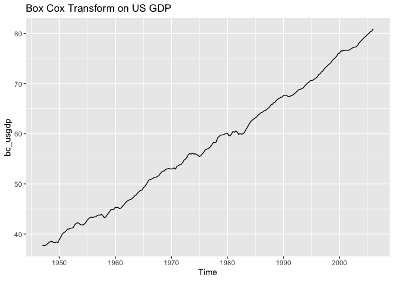

```r
lamb<- BoxCox.lambda(usgdp)
bc_usgdp<- BoxCox(usgdp, lamb)
autoplot(bc_usgdp) + ggtitle("Box Cox Transform on US GDP")
```

Again, an good adjustment to the data. More linear and more reasonable scale.

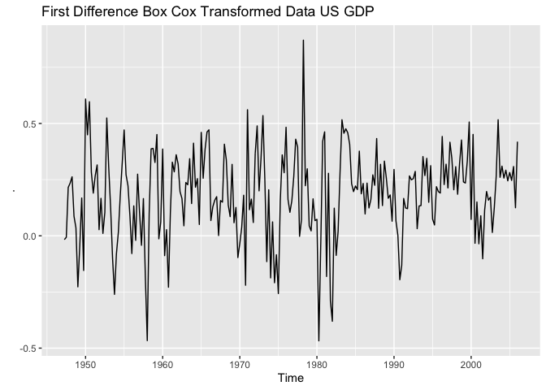

```r
bc_usgdp %>%
  diff() %>%
  autoplot() + ggtitle("First Difference Box Cox Transformed Data US GDP")
```

After some playing with transformed or untransformed data, we again landed on using Box Cox and a first difference. The untransformed first difference of this data also appeared to have a non-constant variance. The above has constant variance in the first difference and thereby is “more” stationary.

### Part C

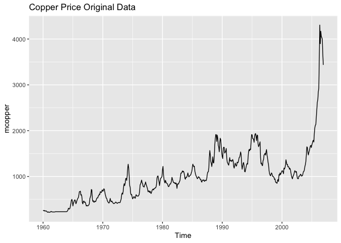

```r
autoplot(mcopper) + ggtitle("Copper Price Original Data")
```

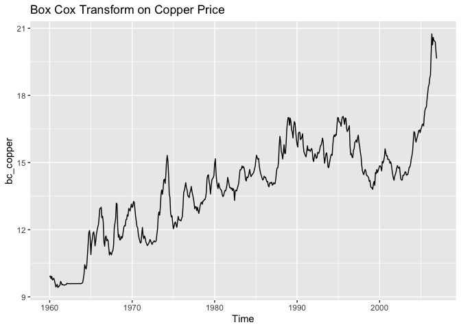

```r
lamb<- BoxCox.lambda(mcopper)
bc_copper<- BoxCox(mcopper, lamb)
autoplot(bc_copper) + ggtitle("Box Cox Transform on Copper Price")
```

Much better in terms of consistent seasonality and reduced scale and the trend appears more clear.

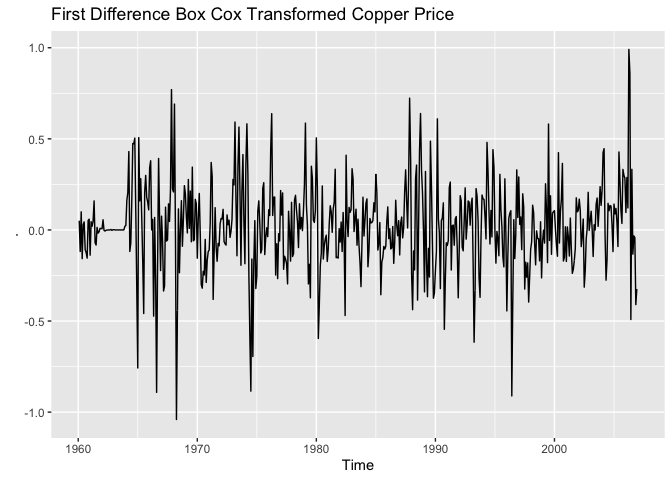

```r
bc_copper %>%
  diff() %>%
  autoplot() + ggtitle("First Difference Box Cox Transformed Copper Price")
```

A quality result from the first difference. This is now stationary data. A second difference was not materiallty different and a call to `ndiffs` returned a value of one.

### Part D

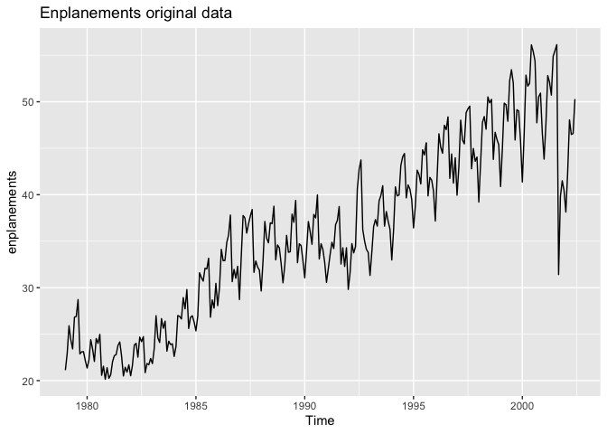

```r
autoplot(enplanements) + ggtitle("Enplanements original data")
```

Seasonal data with some kind of trend overall.

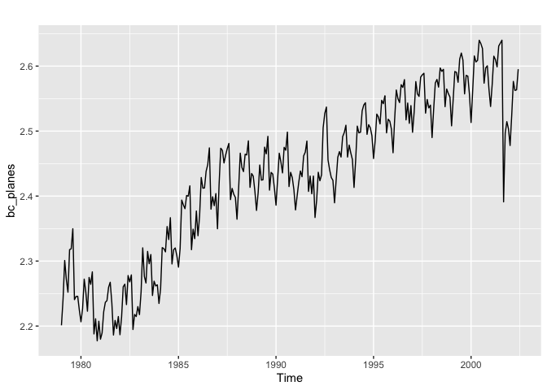

```r
lamb<- BoxCox.lambda(enplanements)
bc_planes <- BoxCox(enplanements, lamb)
autoplot(bc_planes)
```

Given the piece-wise nature of the seasonally adjusted data for this set, Box Cox leaves us wanting more. We explored a log transformation as well as no transformation on the first and second difference of this data and decided on Box Cox and second difference.

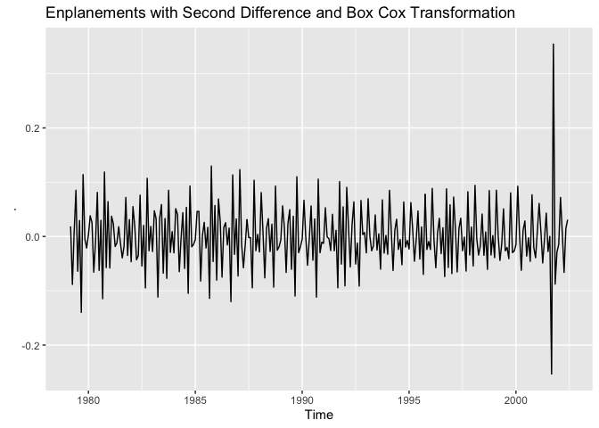

```r
bc_planes %>%
  diff() %>%
  diff() %>%
  autoplot() +
  ggtitle("Enplanements with Second Difference and Box Cox Transformation")
```

This transformation and second difference of the data seems the most stationary since the variance is more constant, and the crash in enplanements is more leveled out in the second difference. The un-transformed and log transformed are similar, but the scale is more centered around zero and crash in values is better modulated.

### Part E

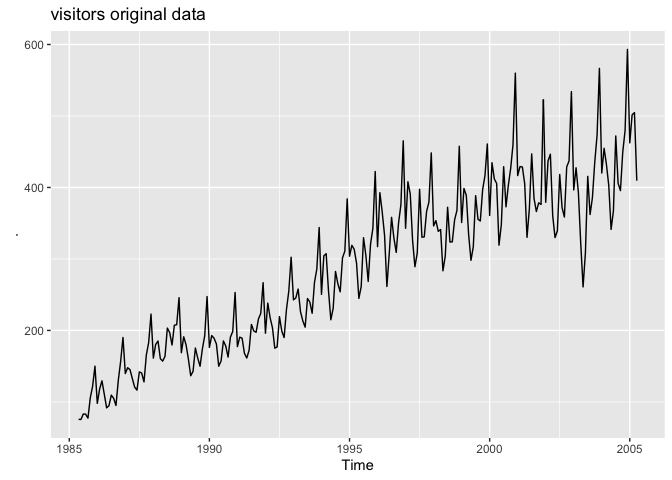

```r
visitors %>% autoplot() + ggtitle("visitors original data")
```

This should be easy for Box Cox and first difference.

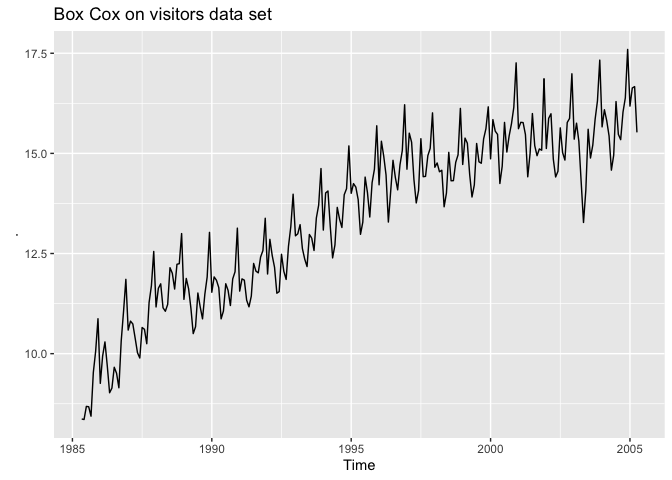

```r
visitors %>%
  BoxCox(.,lambda = BoxCox.lambda(.)) %>%
  autoplot() +
  ggtitle("Box Cox on visitors data set")
```

A good fit.

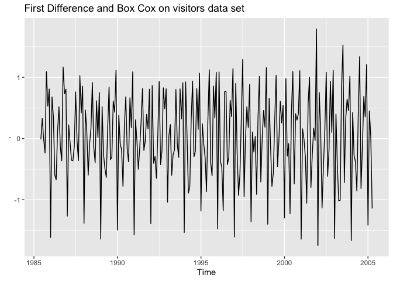

```r
visitors %>%
  BoxCox(.,lambda = BoxCox.lambda(.)) %>%
  diff() %>%
  autoplot() +
  ggtitle("First Difference and Box Cox on visitors data set")
```

The second difference does not confer a meaningful difference in terms of how stationary the data has become.

# Question HA 8.5

## Question

For your retail data (from Exercise 3 in Section 2.10), find an appropriate order of differencing to obtains stationary data.

## Answer

```r
url <- "https://otexts.com/fpp2/extrafiles/retail.xlsx"
GET(url, write_disk("retail.xlsx", overwrite=TRUE))
```

```
## Response [https://otexts.com/fpp2/extrafiles/retail.xlsx]
##   Date: 2021-03-25 15:35
##   Status: 200
##   Content-Type: application/vnd.openxmlformats-officedocument.spreadsheetml.sheet
##   Size: 639 kB
## <ON DISK>  /Users/jeffshamp/Documents/GitHub/cuny_msds/DATA_624/retail.xlsx
```

```r
retail<- readxl::read_excel("retail.xlsx", skip=1)
myts <- ts(retail[, "A3349721R"], frequency = 12, start = c(1982, 1))
```

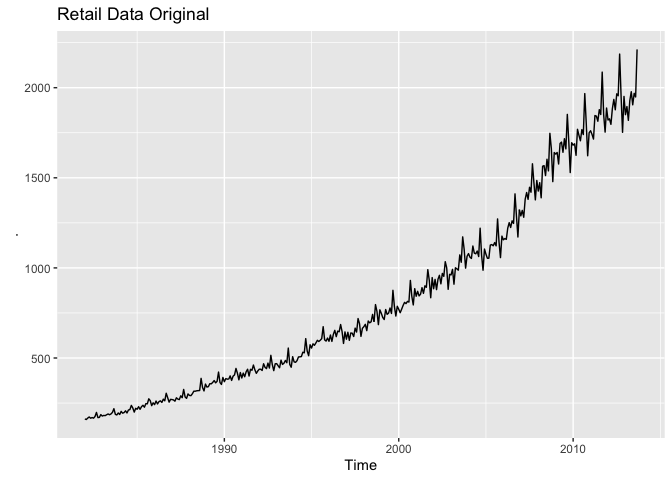

```r
myts %>%
  autoplot() +
  ggtitle("Retail Data Original")
```

Given what we have learned in the previous question, this data set should be well handled by a transform and differencing.

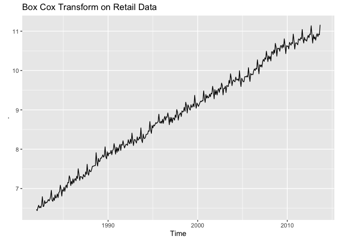

```r
myts %>%
  BoxCox(., lambda = BoxCox.lambda(.)) %>%
  autoplot() +
  ggtitle("Box Cox Transform on Retail Data")
```

Nice. The log transform is not meaningfully different than BC, so maybe that is an alternative.

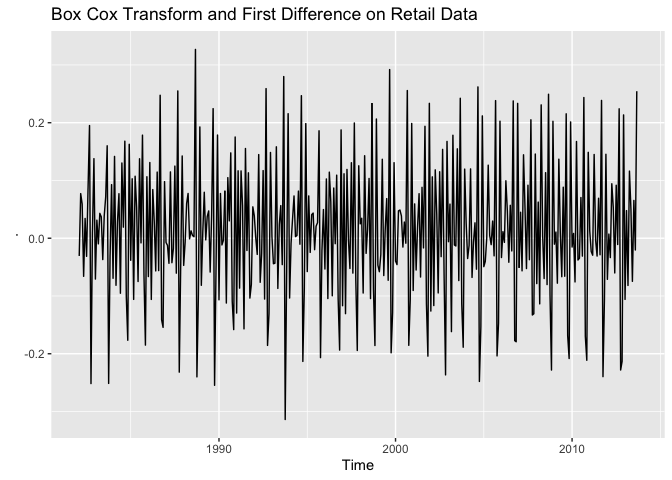

```r
myts %>%
  BoxCox(., lambda = BoxCox.lambda(.)) %>%
  diff() %>%
  autoplot() +
  ggtitle("Box Cox Transform and First Difference on Retail Data")
```

Well stablized from the first difference. The second difference was not meaningfully better in terms of constant variance.

# Question HA 8.6

## Question

Use R to simulate and plot some data from simple ARIMA models.

### Part A

Use the following R code to generate data from an AR(1) model with $\phi_1 = 0.6$ and $\sigma^2 = 1$. The process starts with $y_1 = 0$.

```r
y <- ts(numeric(100))
e <- rnorm(100)
for (i in 2:100)
  y[i] <- 0.6*y[i - 1] + e[i]
```

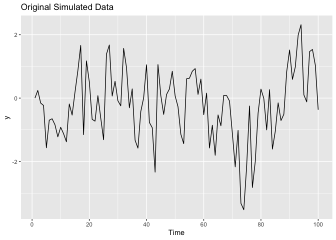

```r
autoplot(y) + ggtitle("Original Simulated Data")
```